# KNN Lab

Sai Rajuladevi, Izzy Shehan, Andrew Porter

4/3/2021

## Problem Statement

- You left your job as a tracking unstructured text as you wanting to expand your skills into predictive models. Luckily you landed a job in advertising! Unfortunately have a demanding and totally clueless boss. Clueless meaning that he doesn’t understand data science, but he knows he wants it to be used to fix all the company’s problems and you are just the data scientist to do it!
- Your company, Marketing Enterprises of Halifax or “MEH” is being beat out by the competition and wants a new way to determine the quality of its commercials. Your boss, Mr. Ed Rooney, would like the company’s commercials to seem more like actual TV shows. So he wants you to develop a “machine learning thing” using the company’s internal data to classify when something is a commercial and when it is not. Mr. Rooney believes the company will be able to make more convincing commercials that hold audiences attention if they are more like tv shows and as a result customers will pay more attention, thus buy more of the terrible products “MEH” is supporting (it’s a terrible plan, but you have to make a living).
- Given that MEH is producing commercials more or less continuously you know there will be a need to update the model quite frequently, also being a newish data scientist and having a clueless boss you decide to use a accessible approach that you might be able to explain to Mr. Rooney, (given several months of dedicated one on one time), that approach is k-nearest neighbor.

## Step 1

- Load in the data, both the commercial dataset and the labels.
- We then placed the labels on the columns.
- The dataset “tv_commercialsets-CNN_Cleaned.csv”, is data collected about the features of commercials on CNN. We can try to predict what segments of video are commercials based on their audio and video components. More information on the datasets can be found [Data World](https://data.world/kramea/tv-commercial-detection/workspace/file?filename=tv_commercial_datasets%2FBBC_Cleaned.csv)

```r
# 1

#You can use the function colnames() to apply the labels (hint: you might need to reshape the labels to make this work)

cnn_labels = read_csv("cnn_commmercial_label.csv", col_names=FALSE)
tv_data = read_csv("tv_commercial_datasets_CNN_Cleaned.csv")

# Get the labels to be on tv_data
colnames(tv_data) <- t(cnn_labels)

kable(tv_data[1:10, c(1:5,ncol(tv_data))])
```

| shot_length | motion_distr_mn | motion_distr_var | frame_diff_dist_mn | frame_diff_dist_var | label |
| --- | --- | --- | --- | --- | --- |
| 29 | 3.821209 | 1.567568 | 13.547628 | 7.242389 | 1 |
| 25 | 3.052969 | 1.641484 | 22.334589 | 15.734018 | 1 |
| 82 | 1.601274 | 1.508805 | 5.860583 | 3.301121 | 1 |
| 25 | 4.819368 | 2.879584 | 41.382828 | 24.448074 | 1 |
| 29 | 2.768753 | 1.797319 | 13.338054 | 9.980667 | 1 |
| 25 | 3.679925 | 2.145892 | 27.195999 | 21.484812 | 1 |
| 113 | 2.782705 | 1.334851 | 11.439361 | 6.420032 | 1 |
| 161 | 1.403820 | 0.785495 | 6.740815 | 4.428925 | 1 |
| 81 | 0.984162 | 0.964449 | 6.858030 | 9.850760 | 1 |
| 116 | 1.262012 | 1.559164 | 6.325819 | 9.576903 | 1 |

## Step 2

- Determine the split between commercial and non-commercial then calculate the base rate, assume 1 is the commercial label and -1 is the non-commercial label

```r
# 2
# Get percentages
pct_comm <- c((nrow(filter(tv_data, label==1)) / nrow(tv_data)))
pct_non_comm <- c((nrow(filter(tv_data, label==-1))/nrow(tv_data)))

# Convert in to a dataframe
tv_pcts = data.frame(
  "percent_commercial" = pct_comm,
  "percent_non_commercial" = pct_non_comm
)
kable(tv_pcts)
```

| percent_commercial | percent_non_commercial |
| --- | --- |
| 0.6392105 | 0.3607895 |

## Step 3

- Since there are columns that contain different metrics for the same variable (i.e. any column that ends in ‘mn’ is the mean of that variable, while any column that ends in ‘var’ is the variance of that variable), we don’t need to keep both, drop all the columns that include var

```r
# 3
# get rid of any column that has var in it
tv_data.clean_var <- tv_data %>% select(-contains("var"))

kable(tv_data.clean_var[1:10, c(1:5,ncol(tv_data.clean_var))])
```

| shot_length | motion_distr_mn | frame_diff_dist_mn | short_time_energy_mn | zcr_mn | label |
| --- | --- | --- | --- | --- | --- |
| 29 | 3.821209 | 13.547628 | 0.019883 | 0.067241 | 1 |
| 25 | 3.052969 | 22.334589 | 0.023027 | 0.077000 | 1 |
| 82 | 1.601274 | 5.860583 | 0.025948 | 0.082317 | 1 |
| 25 | 4.819368 | 41.382828 | 0.014387 | 0.069875 | 1 |
| 29 | 2.768753 | 13.338054 | 0.011506 | 0.100647 | 1 |
| 25 | 3.679925 | 27.195999 | 0.012956 | 0.068125 | 1 |
| 113 | 2.782705 | 11.439361 | 0.016132 | 0.100719 | 1 |
| 161 | 1.403820 | 6.740815 | 0.016213 | 0.125213 | 1 |
| 81 | 0.984162 | 6.858030 | 0.016380 | 0.110147 | 1 |
| 116 | 1.262012 | 6.325819 | 0.015549 | 0.122683 | 1 |

## Step 4

- Before we run kNN, sometimes it’s good to check to make sure that our variables are not highly correlated.

```r
# 4

# Used the cor() function on 'your_dataframe', labelled it 'commercial_correlations', and viewed the data, because remember kNN doesn't work well in high dimensions.
commercial_correlations <- cor(tv_data.clean_var)

kable(commercial_correlations[1:5,1:5])
```

|  | shot_length | motion_distr_mn | frame_diff_dist_mn | short_time_energy_mn | zcr_mn |
| --- | --- | --- | --- | --- | --- |
| shot_length | 1.0000000 | -0.1476257 | -0.1492126 | 0.0264850 | 0.1909047 |
| motion_distr_mn | -0.1476257 | 1.0000000 | 0.7157031 | -0.0071601 | -0.0522060 |
| frame_diff_dist_mn | -0.1492126 | 0.7157031 | 1.0000000 | -0.0239682 | -0.0420741 |
| short_time_energy_mn | 0.0264850 | -0.0071601 | -0.0239682 | 1.0000000 | -0.1250579 |
| zcr_mn | 0.1909047 | -0.0522060 | -0.0420741 | -0.1250579 | 1.0000000 |

## Step 5

- Determine which variables to remove, high correlations start around .7 or below -.7
- We followed the rationale above, and removed the correlations that are above an absolute value of 0.7. Using this process also eliminated groups like motion_distr_mn which was highly correlated with multiple variables like frame_diff_dist_mn and motion_dist_mn.

```r
# 5

# We followed the rationale above, and removed the correlations that are above an absolute value of 0.7. Using this process also eliminated groups like motion_distr_mn which was highly correlated with multiple variables like frame_diff_dist_mn and motion_dist_mn.

tv_data.clean_corr = findCorrelation(commercial_correlations, cutoff=0.7) # put any value as a "cutoff"
tv_data.clean_corr = sort(tv_data.clean_corr)
tv_data.cleaned = tv_data.clean_var[,-c(tv_data.clean_corr)]

kable(colnames(tv_data.clean_var), caption="Original Columns without Variances")
```

Original Columns without Variances

| x |
| --- |
| shot_length |
| motion_distr_mn |
| frame_diff_dist_mn |
| short_time_energy_mn |
| zcr_mn |
| spectral_centroid_mn |
| spectral_roll_off_mn |
| spectral_flux_mn |
| fundamental_freq_mn |
| motion_dist_mn |
| label |

```r
kable(colnames(tv_data.cleaned), caption="Cleaned Columns")
```

Cleaned Columns

| x |
| --- |
| shot_length |
| frame_diff_dist_mn |
| short_time_energy_mn |
| zcr_mn |
| spectral_roll_off_mn |
| fundamental_freq_mn |
| label |

```r
# view the cleaned data and its correlation
kable(tv_data.cleaned[1:10, c(1:5,ncol(tv_data.cleaned))], caption="Cleaned TV Dataset")
```

Cleaned TV Dataset

| shot_length | frame_diff_dist_mn | short_time_energy_mn | zcr_mn | spectral_roll_off_mn | label |
| --- | --- | --- | --- | --- | --- |
| 29 | 13.547628 | 0.019883 | 0.067241 | 6796.552 | 1 |
| 25 | 22.334589 | 0.023027 | 0.077000 | 6610.000 | 1 |
| 82 | 5.860583 | 0.025948 | 0.082317 | 7488.112 | 1 |
| 25 | 41.382828 | 0.014387 | 0.069875 | 6606.001 | 1 |
| 29 | 13.338054 | 0.011506 | 0.100647 | 6688.795 | 1 |
| 25 | 27.195999 | 0.012956 | 0.068125 | 6565.001 | 1 |
| 113 | 11.439361 | 0.016132 | 0.100719 | 7486.948 | 1 |
| 161 | 6.740815 | 0.016213 | 0.125213 | 7499.845 | 1 |
| 81 | 6.858030 | 0.016380 | 0.110147 | 7359.878 | 1 |
| 116 | 6.325819 | 0.015549 | 0.122683 | 7461.855 | 1 |

```r
# And Correlation
kable(cor(tv_data.cleaned), caption="Correlations of Cleaned TV Dataset")
```

Correlations of Cleaned TV Dataset

|  | shot_length | frame_diff_dist_mn | short_time_energy_mn | zcr_mn | spectral_roll_off_mn | fundamental_freq_mn | label |
| --- | --- | --- | --- | --- | --- | --- | --- |
| shot_length | 1.0000000 | -0.1492126 | 0.0264850 | 0.1909047 | 0.3801847 | 0.2926857 | -0.2721069 |
| frame_diff_dist_mn | -0.1492126 | 1.0000000 | -0.0239682 | -0.0420741 | -0.3848395 | -0.0906722 | -0.0474565 |
| short_time_energy_mn | 0.0264850 | -0.0239682 | 1.0000000 | -0.1250579 | 0.1603135 | 0.0225120 | 0.1088148 |
| zcr_mn | 0.1909047 | -0.0420741 | -0.1250579 | 1.0000000 | 0.0330808 | 0.5335548 | -0.2537635 |
| spectral_roll_off_mn | 0.3801847 | -0.3848395 | 0.1603135 | 0.0330808 | 1.0000000 | 0.3249171 | -0.2445148 |
| fundamental_freq_mn | 0.2926857 | -0.0906722 | 0.0225120 | 0.5335548 | 0.3249171 | 1.0000000 | -0.3949560 |
| label | -0.2721069 | -0.0474565 | 0.1088148 | -0.2537635 | -0.2445148 | -0.3949560 | 1.0000000 |

## Step 6

- Generated train and test sets

```r
#6. Use the index to generate a train and test sets, then check the row counts to be safe.
set.seed(1982)
tv_data_train_rows = sample(1:nrow(tv_data.cleaned),#<- from 1 to the number of
                                                     #rows in the data set
                              round(0.8 * nrow(tv_data.cleaned), 0),  #<- multiply the number of rows by 0.8 and round the decimals
                              replace = FALSE)#<- don't replace the numbers

#head(tv_data_train_rows)

# Let's check to make sure we have 80% of the rows.
kable(length(tv_data_train_rows) / nrow(tv_data.cleaned) , caption="Confirmation of 80% of the rows")
```

Confirmation of 80% of the rows

| x |
| --- |
| 0.8 |

```r
tv_data_train = tv_data.cleaned[tv_data_train_rows, ] #<- select the rows identified in the bank_data_train_rows data

kable(tv_data_train[1:10, c(1:5,ncol(tv_data_train))], caption="Training Set")
```

Training Set

| shot_length | frame_diff_dist_mn | short_time_energy_mn | zcr_mn | spectral_roll_off_mn | label |
| --- | --- | --- | --- | --- | --- |
| 28 | 10.919862 | 0.015575 | 0.113728 | 6638.394 | 1 |
| 94 | 17.287212 | 0.008855 | 0.122806 | 7403.992 | 1 |
| 82 | 35.006763 | 0.024365 | 0.073552 | 7450.307 | 1 |
| 32 | 42.724541 | 0.006376 | 0.081738 | 6829.689 | 1 |
| 84 | 3.738151 | 0.024549 | 0.097954 | 7409.225 | 1 |
| 25 | 18.405970 | 0.009217 | 0.107875 | 6460.999 | -1 |
| 32 | 6.532771 | 0.018975 | 0.110059 | 6766.407 | 1 |
| 99 | 10.780879 | 0.017396 | 0.116446 | 7369.447 | -1 |
| 146 | 2.450138 | 0.015306 | 0.117316 | 7484.934 | -1 |
| 46 | 7.302652 | 0.019258 | 0.111889 | 7054.350 | 1 |

```r
tv_data_test = tv_data.cleaned[-tv_data_train_rows, ]  #<- select the rows that weren't identified in the bank_data_train_rows data

kable(tv_data_test[1:10, c(1:5,ncol(tv_data_test))], caption="Testing Set")
```

Testing Set

| shot_length | frame_diff_dist_mn | short_time_energy_mn | zcr_mn | spectral_roll_off_mn | label |
| --- | --- | --- | --- | --- | --- |
| 25 | 41.382828 | 0.014387 | 0.069875 | 6606.001 | 1 |
| 25 | 27.195999 | 0.012956 | 0.068125 | 6565.001 | 1 |
| 81 | 6.858030 | 0.016380 | 0.110147 | 7359.878 | 1 |
| 37 | 9.313793 | 0.010304 | 0.090541 | 6901.352 | 1 |
| 30 | 12.463446 | 0.005663 | 0.126667 | 6668.333 | 1 |
| 101 | 6.009381 | 0.018699 | 0.101516 | 7425.496 | 1 |
| 132 | 17.559553 | 0.011665 | 0.121425 | 7473.482 | 1 |
| 32 | 1.332545 | 0.010307 | 0.086914 | 6755.471 | 1 |
| 123 | 3.901220 | 0.009112 | 0.145046 | 7395.731 | 1 |
| 95 | 16.473642 | 0.015226 | 0.122961 | 7393.683 | 1 |

```r
# Check the number of rows in each set.

printed <- gettextf("Number of training set rows: %s + Number of testing set rows: %s = %s, and the length of the cleaned data is: %s", nrow(tv_data_train), nrow(tv_data_test), nrow(tv_data_train) + nrow(tv_data_test), nrow(tv_data.cleaned))

printed
```

```
## [1] "Number of training set rows: 18036 + Number of testing set rows: 4509 = 22545, and the length of the cleaned data is: 22545"
```

## Step 7

- Train the classifier using k = 3, remember to set.seed so you can repeat the output and to use the labels as a vector for the class (not a index of the dataframe)

```r
# Let's train the classifier for k = 3.
# Install the "class" package that we'll use to run kNN.
# Take some time to learn about all its functionality.
#install.packages("class")
library(class)
library(help = "class")

# k-Nearest Neighbor is a randomized algorithm, so make sure to
# use set.seed() to make your results repeatable.
set.seed(1982)
tv_3NN <-  knn(train = tv_data_train[, colnames(tv_data.cleaned)],#<- training set cases
               test = tv_data_test[, colnames(tv_data.cleaned)],    #<- test set cases
               cl = tv_data_train[, "label", drop=TRUE],#<- category for true classification
               k = 3,#<- number of neighbors considered
               use.all = TRUE,
               prob = TRUE) #<- control ties between class assignments If true, all distances equal to the kth largest are included



# View the output.
str(tv_3NN)
```

```
##  Factor w/ 2 levels "-1","1": 2 2 2 2 1 2 2 2 2 2 ...
##  - attr(*, "prob")= num [1:4509] 0.667 0.667 1 0.667 0.667 ...
```

```r
length(tv_3NN)
```

```
## [1] 4509
```

## Step 8

- Create a initial confusion matrix using the table function and pass it to a object. (xx <- your confusion matrix)

```r
#8 Create a initial confusion matrix using the table function and pass it to a object. (xx <- your confusion matrix)

# How does the kNN classification compare to the true class?
# Let's take a look at the confusion matrix by combining the
# predictions from bank_3NN to the original data set.
kNN_res <- table(tv_3NN,
                tv_data_test$label)
kable(kNN_res, caption= "Initial Confusion Matrix")
```

Initial Confusion Matrix

|  | -1 | 1 |
| --- | --- | --- |
| -1 | 957 | 383 |
| 1 | 665 | 2504 |

```r
# Select the true positives and true negatives by selecting
# only the cells where the row and column names are the same.
kable(kNN_res[row(kNN_res) == col(kNN_res)], caption="True Positives and True Negatives")
```

True Positives and True Negatives

| x |
| --- |
| 957 |
| 2504 |

```r
# Calculate the accuracy rate by dividing the correct classifications
# by the total number of classifications.
kNN_acc <-  sum(kNN_res[row(kNN_res) == col(kNN_res)]) / sum(kNN_res)

kNN_sen <- kNN_res[2,2]/(kNN_res[2,2]+kNN_res[1,2])
sprintf("Sensitivity Calculated: %s", kNN_sen)
```

```
## [1] "Sensitivity Calculated: 0.867336335296155"
```

```r
x <- (kNN_res[1,2])

sprintf("Accuracy Calculated: %s", kNN_acc)
```

```
## [1] "Accuracy Calculated: 0.767575959192726"
```

## Step 9

- Ran the confusion matrix
- We got that the accuracy is 76.76%, the Sensitivity is 86.73%, and the Specificity is 59%. Based on Mr. Rooney’s goal, we should probably choose a specificity that is low.

```r
#9  Run the confusion matrix function and comment on the model output
confusionMatrix(as.factor(tv_3NN), as.factor(tv_data_test$label), positive = "1", dnn=c("Prediction", "Actual"), mode = "sens_spec")
```

```
## Confusion Matrix and Statistics
##
##           Actual
## Prediction   -1    1
##         -1  957  383
##         1   665 2504
##
##                Accuracy : 0.7676
##                  95% CI : (0.755, 0.7798)
##     No Information Rate : 0.6403
##     P-Value [Acc > NIR] : < 2.2e-16
##
##                   Kappa : 0.4755
##
##  Mcnemar's Test P-Value : < 2.2e-16
##
##             Sensitivity : 0.8673
##             Specificity : 0.5900
##          Pos Pred Value : 0.7902
##          Neg Pred Value : 0.7142
##              Prevalence : 0.6403
##          Detection Rate : 0.5553
##    Detection Prevalence : 0.7028
##       Balanced Accuracy : 0.7287
##
##        'Positive' Class : 1
##
```

## Step 10

- We ran the “chooseK” function to find the perfect K, while using sapply() function on chooseK() to test k from 1 to 21 (only selecting the odd numbers), and set the train_set argument to ‘commercial_train’, val_set to ‘commercial_test’, train_class to the “label” column of ‘commercial_train’, and val_class to the “label” column of ‘commercial_test’. Label this “knn_diff_k_com”

```r
#10 Run the "chooseK" function to find the perfect K, while using sapply() function on chooseK() to test k from 1 to 21 (only selecting the odd numbers), and set the train_set argument to 'commercial_train', val_set to 'commercial_test', train_class to the "label"   column of 'commercial_train', and val_class to the "label" column of 'commercial_test'. Label this  "knn_diff_k_com"

# How does "k" affect classification accuracy? Let's create a function
# to calculate classification accuracy based on the number of "k."
chooseK = function(k, train_set, val_set, train_class, val_class){

  # Build knn with k neighbors considered.
  set.seed(1)
  class_knn = knn(train = train_set,    #<- training set cases
                  test = val_set,       #<- test set cases
                  cl = train_class,     #<- category for classification
                  k = k,                #<- number of neighbors considered
                  use.all = TRUE)       #<- control ties between class assignments#   If true, all distances equal to the kth largest are included
  conf_mat = table(class_knn, val_class)

  # Calculate the accuracy#could change this to Sensitivity
  accu = sum(conf_mat[row(conf_mat) == col(conf_mat)]) / sum(conf_mat)
  cbind(k = k, accuracy = accu)
}


# The sapply() function plugs in several values into our chooseK function.
#sapply(x, fun...) "fun" here is passing a function to our k-function
# function(x)[function] allows you to apply a series of numbers
# to a function without running a for() loop! Returns a matrix.
knn_different_k = sapply(seq(1, 21, by = 2),  #<- set k to be odd number from 1 to 21
                         function(x) chooseK(x,
                                             train_set = tv_data_train[, colnames(tv_data.cleaned)],
                                             val_set = tv_data_test[, colnames(tv_data.cleaned)],
                                             train_class = tv_data_train[, "label", drop=TRUE],
                                             val_class = tv_data_test[, "label", drop=TRUE]))
#knn_different_k
```

## Step 11

- Create a dataframe so we can visualize the difference in accuracy based on K, convert the matrix to a dataframe

```r
# 11
# Reformatting the results to graph

knn_different_k = data.frame(k = knn_different_k[1,],
                             accuracy = knn_different_k[2,])

kable(knn_different_k)
```

| k | accuracy |
| --- | --- |
| 1 | 0.7600355 |
| 3 | 0.7677977 |
| 5 | 0.7726769 |
| 7 | 0.7788867 |
| 9 | 0.7777778 |
| 11 | 0.7779996 |
| 13 | 0.7775560 |
| 15 | 0.7782213 |
| 17 | 0.7788867 |
| 19 | 0.7753382 |
| 21 | 0.7755600 |

## Step 12

- Use ggplot to show the output
- We should select K=7 or K=17 as they have the highest accuracy values

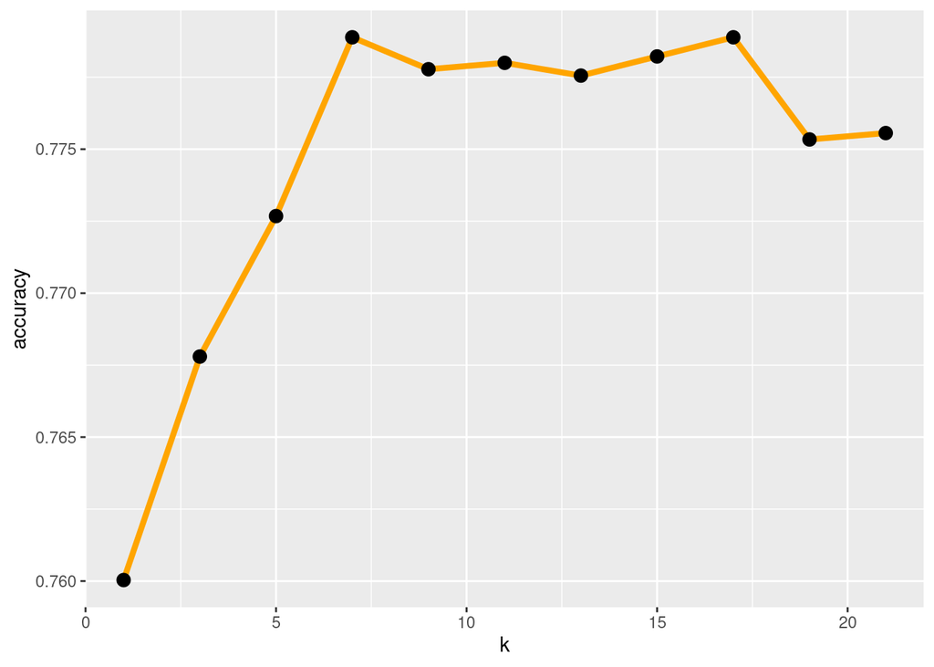

```r
#12 Use ggplot to show the output and comment on the k to select.
ggplot(knn_different_k,
       aes(x = k, y = accuracy)) +
  geom_line(color = "orange", size = 1.5) +
  geom_point(size = 3)
```

```r
# We should select K=7 or K=17 as they have the highest accuracies
```

## Step 13

- We reran the model with the k=7 we selected, assuming it’s different.

```r
#13 Rerun the model  with the k you selected, assuming it's different.

tv_7NN <-  knn(train = tv_data_train[, colnames(tv_data.cleaned)],
               test = tv_data_test[, colnames(tv_data.cleaned)],
               cl = tv_data_train[, "label", drop=TRUE],
               k = 7,
               use.all = TRUE,
               prob = TRUE)
```

## Step 14

- Use the confusion matrix function to measure the quality of the new model.

```r
#14 Use the confusion matrix function to measure the quality of the new model.
confusionMatrix(as.factor(tv_7NN), as.factor(tv_data_test$label), positive = "1", dnn=c("Prediction", "Actual"), mode = "sens_spec")
```

```
## Confusion Matrix and Statistics
##
##           Actual
## Prediction   -1    1
##         -1  934  310
##         1   688 2577
##
##                Accuracy : 0.7787
##                  95% CI : (0.7663, 0.7907)
##     No Information Rate : 0.6403
##     P-Value [Acc > NIR] : < 2.2e-16
##
##                   Kappa : 0.4937
##
##  Mcnemar's Test P-Value : < 2.2e-16
##
##             Sensitivity : 0.8926
##             Specificity : 0.5758
##          Pos Pred Value : 0.7893
##          Neg Pred Value : 0.7508
##              Prevalence : 0.6403
##          Detection Rate : 0.5715
##    Detection Prevalence : 0.7241
##       Balanced Accuracy : 0.7342
##
##        'Positive' Class : 1
##
```

## Step 15

```r
#15 Summarize the differences in language Mr. Rooney may actually understand. Include a discussion on which approach k=3 or k="optimal" is the better method moving forward for "MEH". Most importantly draft comments about the overall approach and model quality as it relates to addressing the problem proposed by Ed.
```

- Our results were that the k=3 method had an accuracy of 76.76%, and a sensitivity of 86.73%. The k=7 (optimal) method on the other hand had an accuracy of 77.87% and a sensitivity of 89.26%.
- Our base rate was about 63.9%.
- Since “MEH” wants to make commercials that are more like TV shows, it would be beneficial to observe when a commercial is classified as a false negative- basically when a TV clip is said not to be a commercial when it actually is. For Mr. Rooney, a k=7 (optimal approach) compared to a k=3 approach might help out with diagnosing true positives since the sensitivity increases (when a TV clip is said to be a commercial and it actually is).
- Next time it might be beneficial to lower the specificity value, as with a K=3 it is 59% and with a K=7 it is 57%. The lower the specificity (true negatives), the better the model would be. This would roughly translate to lowering the rate that non-commercials are correctly predicted.